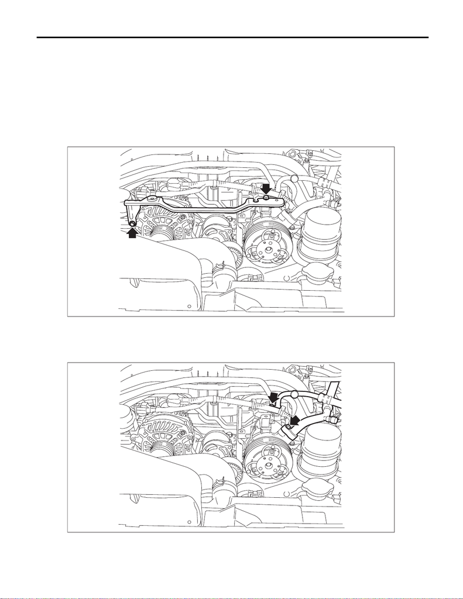

AC-45

Compressor

HVAC SYSTEM (HEATER, VENTILATOR AND A/C)

14.Compressor

A: REMOVAL

1. EXCEPT FOR STI MODEL

1) Perform compressor oil return operation. <Ref. to AC-34, PROCEDURE, Compressor Oil.>

2) Using the refrigerant recovery system, discharge refrigerant. <Ref. to AC-26, PROCEDURE, Refrigerant

Recovery Procedure.>

3) Disconnect the ground terminal from battery sensor. <Ref. to NT-5, BATTERY, NOTE, Note.>

4) Remove the V-belts. <Ref. to ME(w/o STI)-78, REMOVAL, V-belt.>

5) Remove the bolts and remove the V-belt cover bracket.

6) Remove the bolt, and detach the hose - pressure suction and the hose - pressure discharge.

CAUTION:

Seal the disconnected hose and engaging part of compressor with a plug or vinyl tape to prevent for-

eign matter from entering.

AC-03529

AC-03528

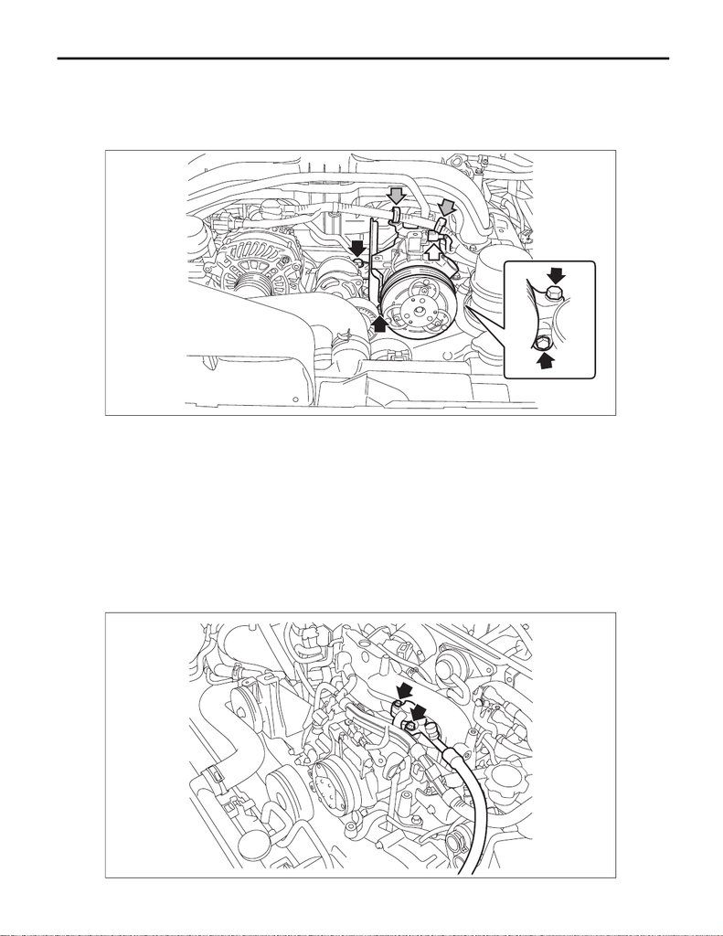

AC-46

Compressor

HVAC SYSTEM (HEATER, VENTILATOR AND A/C)

7) Remove the compressor assembly.

(1) Remove the harness clamp and connector.

(2) Remove the bolts and remove the compressor assembly.

NOTE:

Tighten the engine hanger together with the compressor assembly.

2. STI MODEL

1) Perform compressor oil return operation. <Ref. to AC-34, PROCEDURE, Compressor Oil.>

2) Using the refrigerant recovery system, discharge refrigerant. <Ref. to AC-26, PROCEDURE, Refrigerant

Recovery Procedure.>

3) Disconnect the ground cable from battery.

4) Remove the V-belts. <Ref. to ME(STI)-41, REMOVAL, V-belt.>

5) Remove the generator. <Ref. to SC(STI)-15, REMOVAL, Generator.>

6) Remove the secondary air pump. <Ref. to EC(STI)-53, REMOVAL, Secondary Air Pump.>

7) Remove the bolt, and detach the hose - pressure suction and the hose - pressure discharge.

CAUTION:

Seal the disconnected hose and engaging part of compressor with a plug or vinyl tape to prevent for-

eign matter from entering.

AC-03527

AC-03532

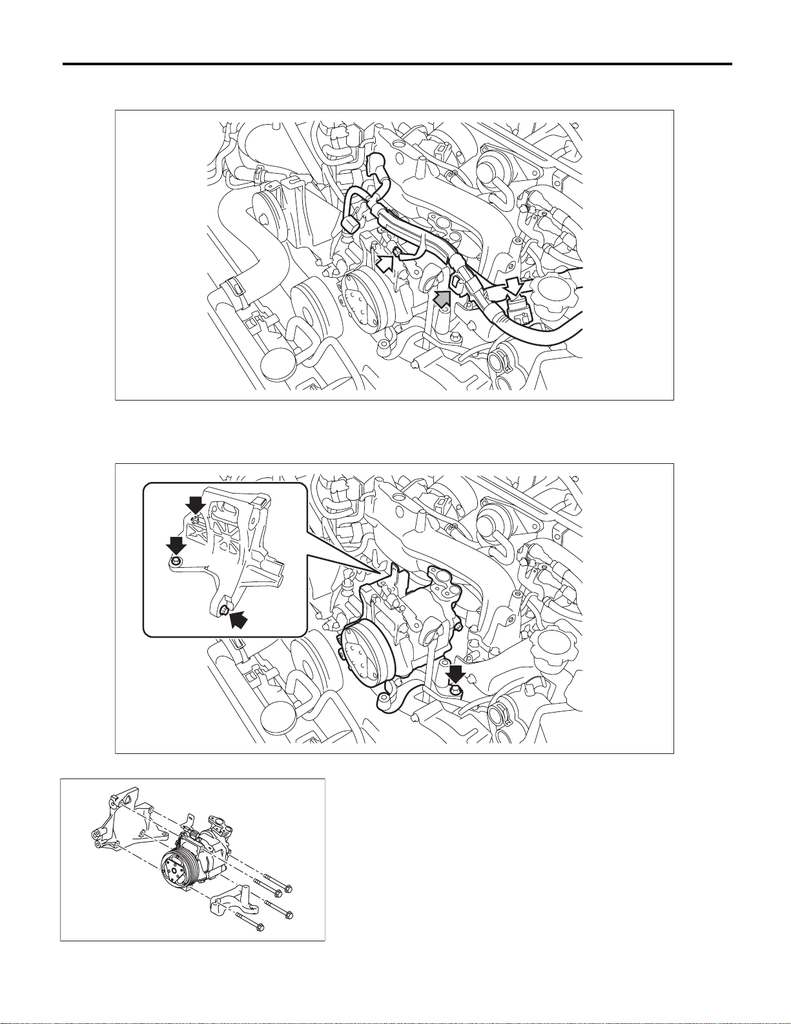

AC-47

Compressor

HVAC SYSTEM (HEATER, VENTILATOR AND A/C)

8) Remove the compressor assembly.

(1) Detach the harness clamp and each connector.

(2) Remove the bolts and remove the compressor assembly.

NOTE:

Since the compressor cannot be removed by itself, remove the compressor bracket as a unit.

(3) Remove the bracket assembly - compressor and the bracket - air conditioner.

AC-03531

AC-03530

AC-02484

[figure not shown]

AC-48

Compressor

HVAC SYSTEM (HEATER, VENTILATOR AND A/C)

B: INSTALLATION

1. EXCEPT FOR STI MODEL

CAUTION:

• Replace the O-rings on the hose - pressure suction and discharge with new parts, and then apply

compressor oil.

• After replacing the compressor assembly, adjust the amount of the compressor oil. <Ref. to AC-34,

ADJUSTMENT, Compressor Oil.>

1) Install the compressor assembly.

Tightening torque:

36 N·m (3.7 kgf-m, 26.6 ft-lb)

2) Install the hose - pressure suction and the hose - pressure discharge.

Tightening torque:

10 N·m (1.0 kgf-m, 7.4 ft-lb)

3) Install the V-belt cover bracket.

Tightening torque:

6.4 N·m (0.7 kgf-m, 4.7 ft-lb)

4) Install the V-belts. <Ref. to ME(w/o STI)-81, INSTALLATION, V-belt.>

5) Connect the ground terminal to battery sensor. <Ref. to NT-5, BATTERY, NOTE, Note.>

6) Charge refrigerant. <Ref. to AC-27, PROCEDURE, Refrigerant Charging Procedure.>

2. STI MODEL

CAUTION:

• Replace the O-rings on the hose - pressure suction and discharge with new parts, and then apply

compressor oil.

• After replacing the compressor assembly, adjust the amount of the compressor oil. <Ref. to AC-34,

ADJUSTMENT, Compressor Oil.>

1) Install the bracket assembly - compressor and the bracket - air conditioner.

Tightening torque:

26.5 N·m (2.7 kgf-m, 19.5 ft-lb)

2) Install the compressor assembly.

Tightening torque:

36 N·m (3.7 kgf-m, 26.6 ft-lb)

3) Install the hose - pressure suction and the hose - pressure discharge.

Tightening torque:

10 N·m (1.0 kgf-m, 7.4 ft-lb)

4) Install the secondary air pump. <Ref. to EC(STI)-53, INSTALLATION, Secondary Air Pump.>

5) Install the generator. <Ref. to SC(STI)-15, INSTALLATION, Generator.>

6) Install the V-belts. <Ref. to ME(STI)-41, INSTALLATION, V-belt.>

7) Connect the battery ground terminal.

8) Charge refrigerant. <Ref. to AC-27, PROCEDURE, Refrigerant Charging Procedure.>

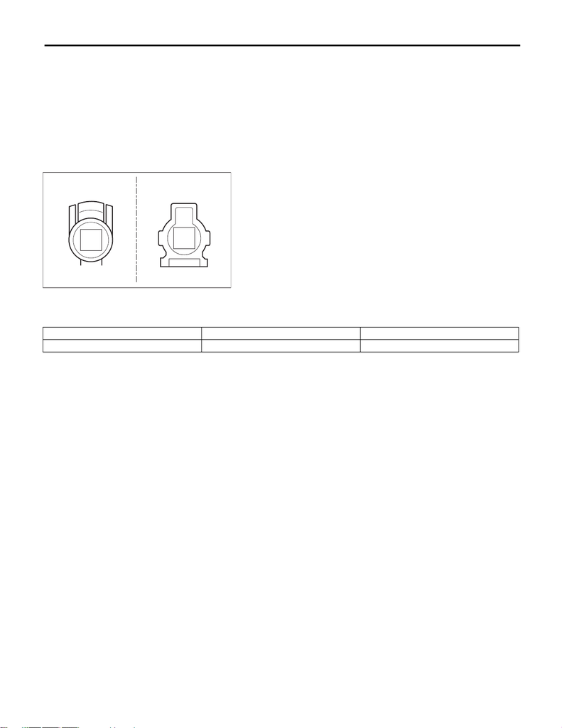

AC-49

Compressor

HVAC SYSTEM (HEATER, VENTILATOR AND A/C)

C: INSPECTION

1. MAGNET CLUTCH CLEARANCE INSPECTION

1) Check the clearance of entire circumference around the drive plate and pulley.

Specification:

0.3 — 0.6 mm (0.0118 — 0.0236 in)

2) Replace the compressor assembly if the inspection result is not within the standard.

2. MAGNET CLUTCH OPERATION INSPECTION

1) Check the magnet clutch operation when battery voltage is applied to the connector terminal.

2) If it does not operate normally, replace the compressor assembly.

(A) Except for STI model

(B) STI model

AC-03533

1

1

(A) (B)

Terminal No. Inspection conditions Specification

1 (+) — Chassis ground (–) Apply battery voltage. Engaged